# SU_25_River_Rockfish_Proj_Fecundity_Ambient_V0.2

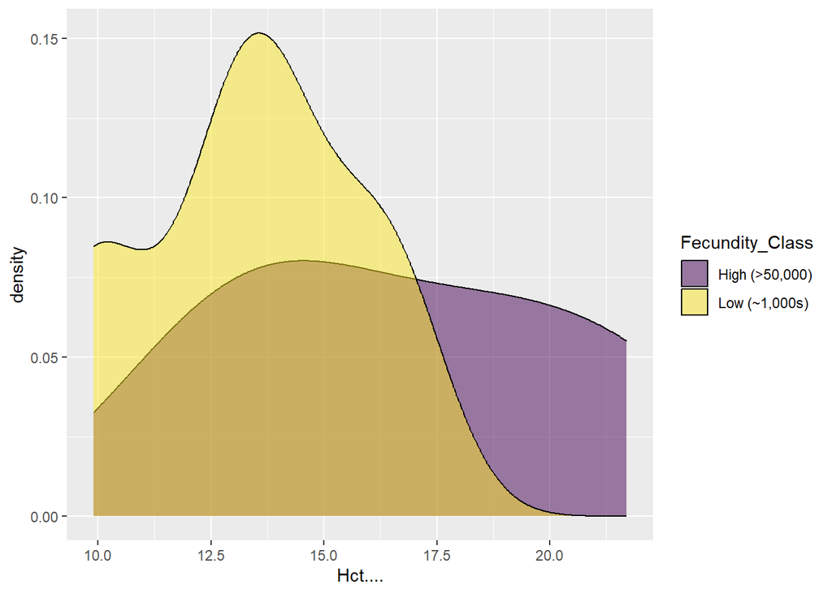

```r
# Density by brood condition
Amb_Fec_No_Atresia_Samples %>%
ggplot(aes(x = Hct....)) +
  geom_density(aes(x = Hct...., fill = Fecundity_Class), alpha = 0.5)
```

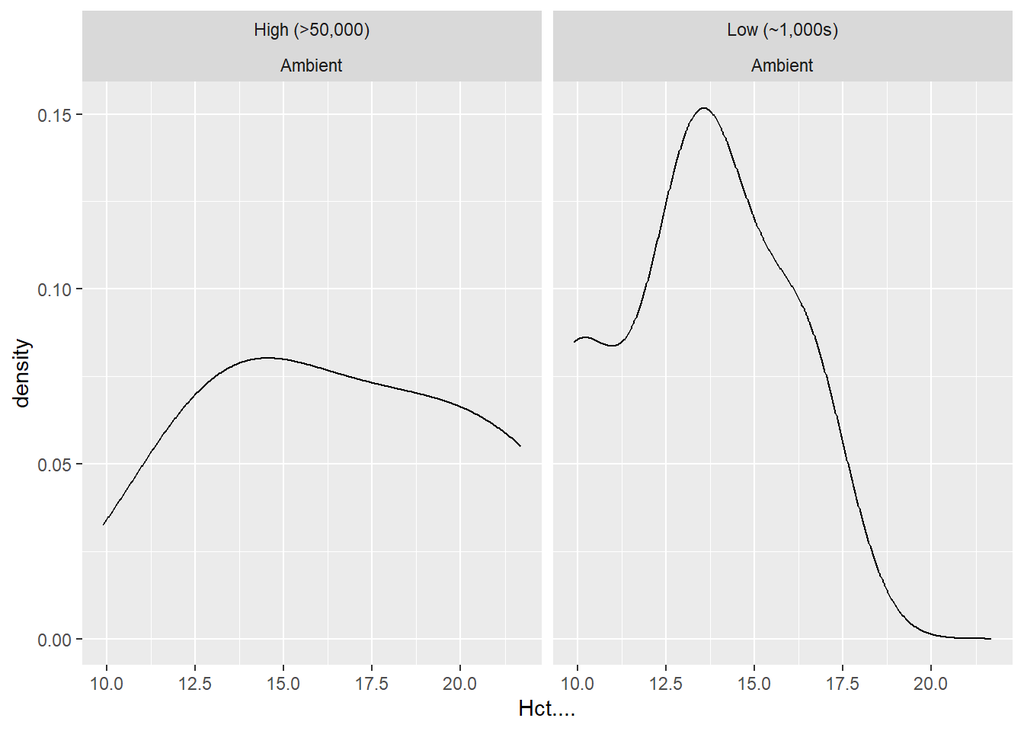

```r
ggplot(Amb_Fec_No_Atresia_Samples, aes(x = Hct....)) +
  geom_density(aes(x = Hct....)) +
  facet_wrap(Fecundity_Class ~ Ambient.Or.OAH)
```

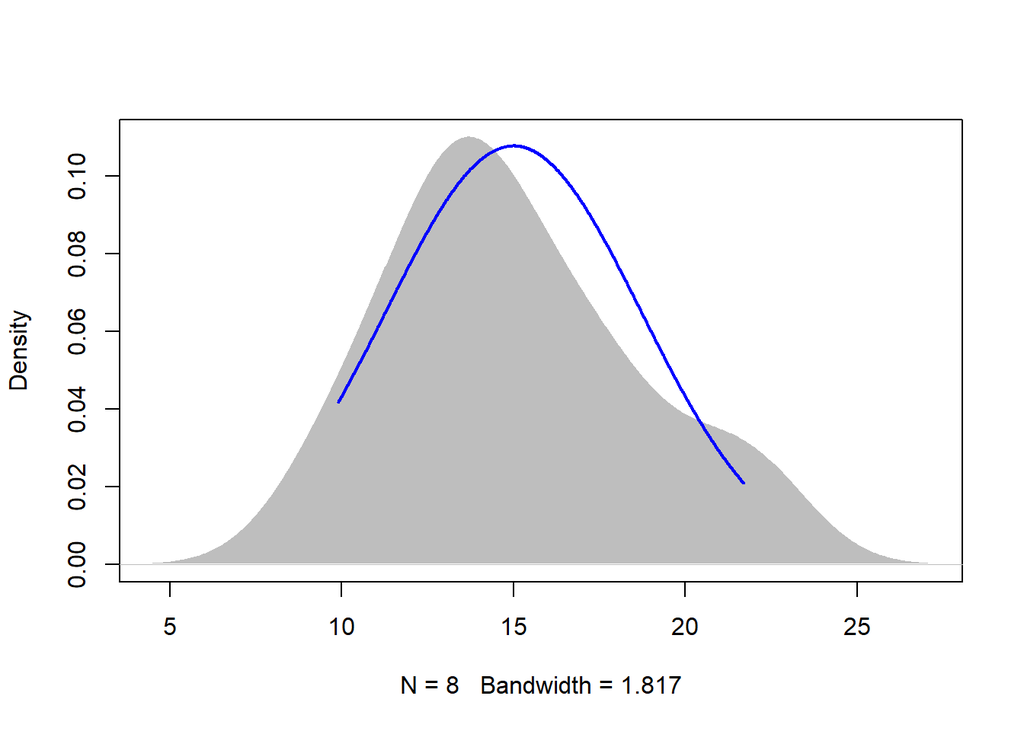

```r
plotNormalDensity(Amb_Fec_No_Atresia_Samples$Hct....)
```

# Hct Stat Tests

Model Design

```r
# Hct

# Amb Fec No Atresia regression model

hct_amb_fec_no_atresia_lm <- lm(Hct.... ~ All_Fecundity, data = Amb_Fec_No_Atresia_Samples)

hct_amb_fec_no_atresia_lm_res <- residuals(hct_amb_fec_no_atresia_lm)

# p-value significant if (a < 0.1 or a < 0.05)
summary(hct_amb_fec_no_atresia_lm)
```

```
##
## Call:
## lm(formula = Hct.... ~ All_Fecundity, data = Amb_Fec_No_Atresia_Samples)
##
## Residuals:
##    Min     1Q Median     3Q    Max
## -3.618 -1.100 -0.817  0.156  6.154
##
## Coefficients:
##                Estimate Std. Error t value Pr(>|t|)
## (Intercept)   1.079e+01  2.392e+00   4.514  0.00404 **
## All_Fecundity 8.057e-05  4.069e-05   1.980  0.09503 .
## ---
## Signif. codes:  0 '***' 0.001 '**' 0.01 '*' 0.05 '.' 0.1 ' ' 1
##
## Residual standard error: 3.11 on 6 degrees of freedom
## Multiple R-squared:  0.3952, Adjusted R-squared:  0.2944
## F-statistic:  3.92 on 1 and 6 DF,  p-value: 0.09503
```

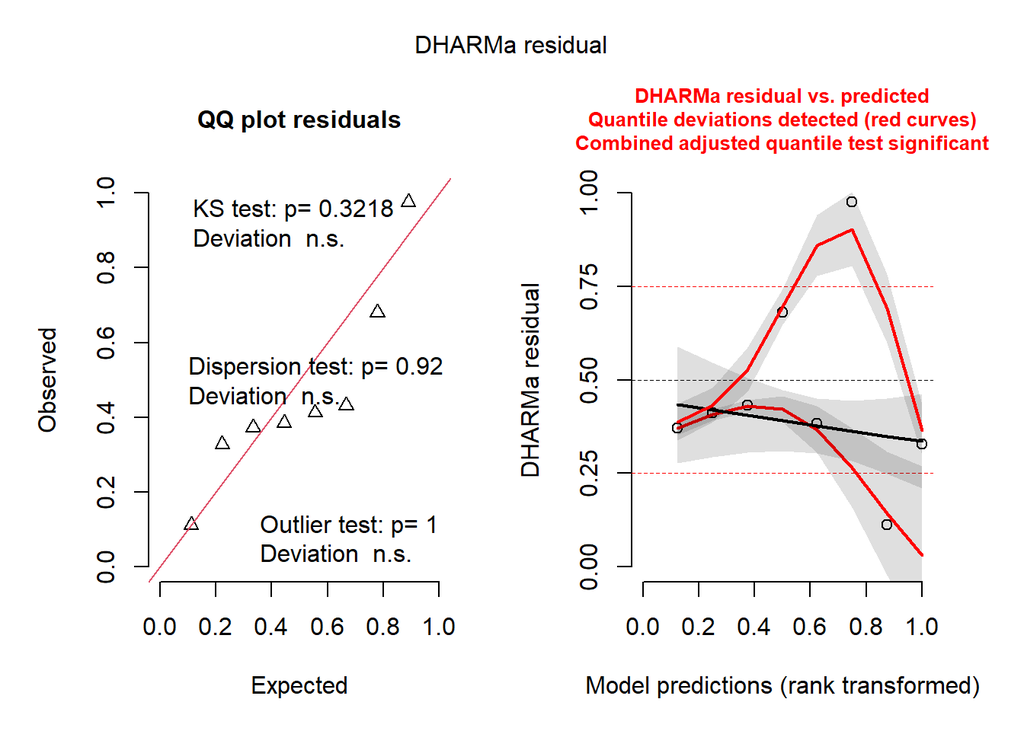

```r
hct_amb_fec_no_atresia_lm_res_plot <- simulateResiduals(fittedModel = hct_amb_fec_no_atresia_lm)
plot(hct_amb_fec_no_atresia_lm_res_plot)
```

```r
# Normality test
shapiro.test(hct_amb_fec_no_atresia_lm_res)
```

```
##
##  Shapiro-Wilk normality test
##
## data:  hct_amb_fec_no_atresia_lm_res
## W = 0.83963, p-value = 0.07467
```

```r
# scedasticity test requires a categorical variable

# Non-parametric stat test:
kruskal.test(Hct.... ~ All_Fecundity, data = Amb_Fec_No_Atresia_Samples)
```

```
##
##  Kruskal-Wallis rank sum test
##
## data:  Hct.... by All_Fecundity
## Kruskal-Wallis chi-squared = 7, df = 7, p-value = 0.4289
```

```r
#DunnTest(Hct.... ~ All_Fecundity, data = Amb_Fec_No_Atresia_Samples)
# Not greatest method for this test...
```

Check Dispersion or Outliers

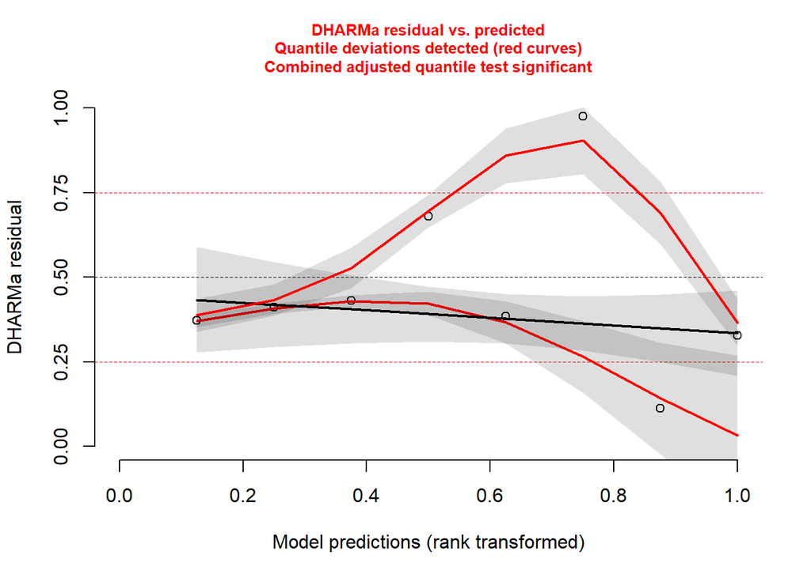

```r
plotResiduals(hct_amb_fec_no_atresia_lm)
```

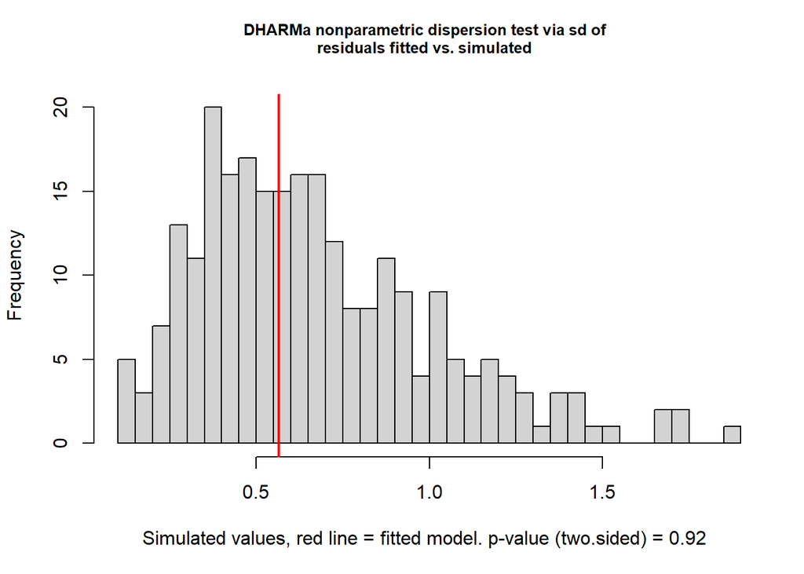

```
##
##  DHARMa nonparametric dispersion test via sd of residuals fitted vs.
##  simulated
##
## data:  simulationOutput
## dispersion = 0.84221, p-value = 0.92
## alternative hypothesis: two.sided
```

```r
testDispersion(hct_amb_fec_no_atresia_lm)
```

Parametric Assumptions:

Residuals Plot (if significant)

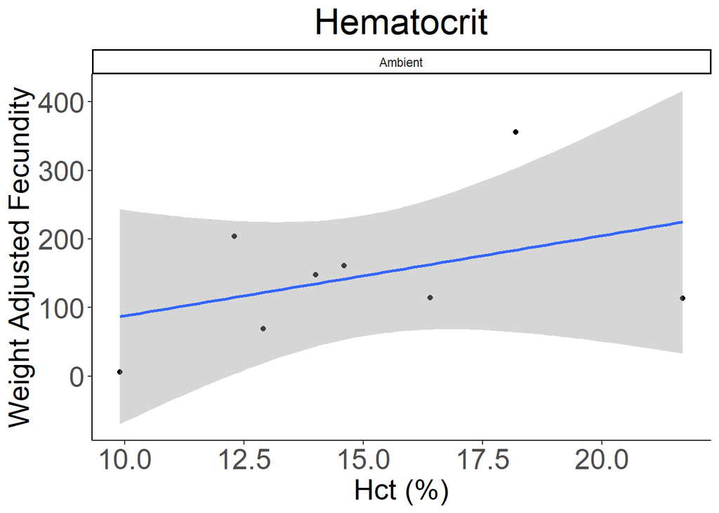

```r
# Hct
# ggplot with geom_smooth(aes(x=,y=)), method = "lm")

# Amb Fec only scatterplot: atresia ids removed
hct_amb_fec_no_atresia_weight_adj_lm_scatterplot <- ggplot(data = Amb_Fec_No_Atresia_Samples) +
  geom_point(aes(x = Hct...., y = Weight_Adjusted_Fecundity_Fecundity.Mean_Weight), colour = "black") +
  geom_smooth(aes(x = Hct...., y = Weight_Adjusted_Fecundity_Fecundity.Mean_Weight), method = "lm") +
  labs(title = "Hematocrit", x = "Hct (%)", y = "Weight Adjusted Fecundity") +
  scale_y_continuous() +
  theme_classic() +
  facet_wrap(~ Ambient.Or.OAH) +
  theme(panel.background = element_rect(fill = "white"),
        plot.background = element_rect(fill = "white"),
        legend.background = element_rect(fill = "white", color = "black"),
        plot.title = element_text(size = 25, hjust = 0.5),
        axis.text.x = element_text(size = 20),
        axis.text.y = element_text(size = 20),
        axis.title.x = element_text(size = 20),
        axis.title.y = element_text(size = 20))

print(hct_amb_fec_no_atresia_weight_adj_lm_scatterplot)
```

```r
ggsave(filename = "data-images/hct_amb_fec_no_atresia_weight_adj_lm_scatterplot.pdf", plot = hct_amb_fec_no_atresia_weight_adj_lm_scatterplot, device = "pdf")
ggsave(filename = "data-images/hct_amb_fec_no_atresia_weight_adj_lm_scatterplot.png", plot = hct_amb_fec_no_atresia_weight_adj_lm_scatterplot, device = "png")
```

Model For Fecundity Class (No Atresia)

```r
# Hct
# Amb Fec No Atresia Class regression model

hct_amb_fec_no_atresia_aov_cat <- aov(Hct.... ~ Fecundity_Class, data = Amb_Fec_No_Atresia_Samples)

summary(hct_amb_fec_no_atresia_aov_cat)
```

```
##                 Df Sum Sq Mean Sq F value Pr(>F)
## Fecundity_Class  1  23.12   23.12   1.904  0.217
## Residuals        6  72.84   12.14
```

```r
TukeyHSD(hct_amb_fec_no_atresia_aov_cat)
```

```
##   Tukey multiple comparisons of means
##     95% family-wise confidence level
##
## Fit: aov(formula = Hct.... ~ Fecundity_Class, data = Amb_Fec_No_Atresia_Samples)
##
## $Fecundity_Class
##                              diff       lwr      upr     p adj
## Low (~1,000s)-High (>50,000) -3.4 -9.428547 2.628547 0.2167991
```

```r
# Normality test
shapiro.test(Amb_Fec_No_Atresia_Samples$Hct....)
```

```
##
##  Shapiro-Wilk normality test
##
## data:  Amb_Fec_No_Atresia_Samples$Hct....
## W = 0.97097, p-value = 0.9055
```

```r
# Parametric variance test:
bartlett.test(Hct.... ~ Fecundity_Class, data = Amb_Fec_No_Atresia_Samples)
```

```
##
##  Bartlett test of homogeneity of variances
##
## data:  Hct.... by Fecundity_Class
## Bartlett's K-squared = 0.45049, df = 1, p-value = 0.5021
```

```r
# Non-parametric variance test:
# Levene's test requires a categorical variable
#LeveneTest(Hct.... ~ Fecundity_Class, data = Amb_Fec_No_Atresia_Samples)
```

Results: Ambient Fecundity No Atresia Sample

- No significant difference in Hct between fecundity classes: Low (~1,000s) vs. High (>50,000) (p adj = 0.2167991)

Parametric Assumptions: Across Sample comparisons…

- Sample size (n > 30): **Not Met**
- Normality: **Met**
- Homoscedasticity: **Met**

Model For Fecundity Class (With Atresia)

```r
# Hct
# Amb Fec Class regression model

hct_amb_fec_aov_cat <- aov(Hct.... ~ Fecundity_Class, data = Amb_Fec_Samples)

summary(hct_amb_fec_aov_cat)
```

```
##                 Df Sum Sq Mean Sq F value Pr(>F)
## Fecundity_Class  2  73.83   36.92   4.824  0.021 *
## Residuals       18 137.74    7.65
## ---
## Signif. codes:  0 '***' 0.001 '**' 0.01 '*' 0.05 '.' 0.1 ' ' 1
```

```r
TukeyHSD(hct_amb_fec_aov_cat)
```

```
##   Tukey multiple comparisons of means
##     95% family-wise confidence level
##
## Fit: aov(formula = Hct.... ~ Fecundity_Class, data = Amb_Fec_Samples)
##
## $Fecundity_Class
##                              diff        lwr      upr     p adj
## Low (~1,000s)-High (>50,000) -3.4 -8.3921454 1.592145 0.2186627
## Atresia-High (>50,000)        1.5 -2.5366864 5.536686 0.6176987
## Atresia-Low (~1,000s)         4.9  0.8633136 8.936686 0.0162654
```

```r
# Normality test
shapiro.test(Amb_Fec_Samples$Hct....)
```

```
##
##  Shapiro-Wilk normality test
##
## data:  Amb_Fec_Samples$Hct....
## W = 0.97482, p-value = 0.8355
```

```r
# Parametric variance test:
bartlett.test(Hct.... ~ Fecundity_Class, data = Amb_Fec_Samples)
```

```
##
##  Bartlett test of homogeneity of variances
##
## data:  Hct.... by Fecundity_Class
## Bartlett's K-squared = 1.7219, df = 2, p-value = 0.4228
```

```r
# Non-parametric variance test:
# Levene's test requires a categorical variable
#LeveneTest(Hct.... ~ Fecundity_Class, data = Amb_Fec_Samples)
```

Results: Ambient Fecundity Sample (With Atresia)

- A **significant** difference in Hct between fecundity classes: Low (~1,000s), High (>50,000), and Atresia
- Evidence: Pr(>F) = 0.021 *
- Atresia-Low (~1,000s) significantly different (p adj = 0.0162654).
  - Atresia group display a significant increase in hematocrit compared to Low fecundity group

Parametric Assumptions: Across Sample comparisons…

- Sample size (n > 30): **Not Met**
- Normality: **Met**
- Homoscedasticity: **Met**

# Glucose

Glucose Summary Stats

```r
# glucose
# Summary stats

# Amb Fec data (with atresia IDs)
Amb_Fec_Samples %>%
  group_by(Ambient.Or.OAH, Fecundity_Class) %>%
  summarize(count = n(),
            median = round(median(Glu..mmol.L.), 3),
            mean = round(mean(Glu..mmol.L.), 3),
            sd = round(sd(Glu..mmol.L.), 3),
            cv = round(sd(Glu..mmol.L.)/mean(Glu..mmol.L.), 3)) %>%
  ungroup()
```

```
## # A tibble: 3 × 7
##   Ambient.Or.OAH Fecundity_Class count median  mean    sd    cv
##   <chr>          <ord>           <int>  <dbl> <dbl> <dbl> <dbl>
## 1 Ambient        High (>50,000)      4   1.55  1.55 0.238 0.154
## 2 Ambient        Low (~1,000s)       4   1.5   1.68 0.866 0.517
## 3 Ambient        Atresia            13   2     2.1  0.698 0.332
```

```r
# Amb Fec No Atresia data
Amb_Fec_No_Atresia_Samples %>%
  group_by(Ambient.Or.OAH, Fecundity_Class) %>%
  summarize(count = n(),
            median = round(median(Glu..mmol.L.), 3),
            mean = round(mean(Glu..mmol.L.), 3),
            sd = round(sd(Glu..mmol.L.), 3),
            cv = round(sd(Glu..mmol.L.)/mean(Glu..mmol.L.), 3)) %>%
  ungroup()
```

```
## # A tibble: 2 × 7
##   Ambient.Or.OAH Fecundity_Class count median  mean    sd    cv
##   <chr>          <ord>           <int>  <dbl> <dbl> <dbl> <dbl>
## 1 Ambient        High (>50,000)      4   1.55  1.55 0.238 0.154
## 2 Ambient        Low (~1,000s)       4   1.5   1.68 0.866 0.517
```

Data Graphs:

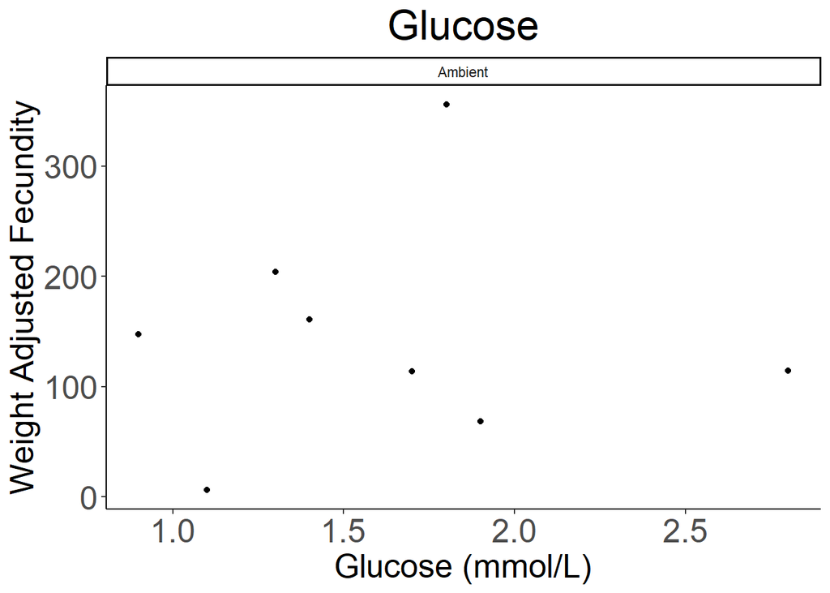

```r
# glucose
# Weight adjusted scatterplot

# Amb Fec only scatterplot: atresia ids removed
glucose_amb_fec_no_atresia_weight_adj_scatterplot <- ggplot(data = Amb_Fec_No_Atresia_Samples) +
  geom_point(aes(x = Glu..mmol.L., y = Weight_Adjusted_Fecundity_Fecundity.Mean_Weight), colour = "black") +
  labs(title = "Glucose", x = "Glucose (mmol/L)", y = "Weight Adjusted Fecundity") +
  scale_y_continuous() +
  theme_classic() +
  facet_wrap(~ Ambient.Or.OAH) +
  theme(panel.background = element_rect(fill = "white"),
        plot.background = element_rect(fill = "white"),
        legend.background = element_rect(fill = "white", color = "black"),
        plot.title = element_text(size = 25, hjust = 0.5),
        axis.text.x = element_text(size = 20),
        axis.text.y = element_text(size = 20),
        axis.title.x = element_text(size = 20),
        axis.title.y = element_text(size = 20))

print(glucose_amb_fec_no_atresia_weight_adj_scatterplot)
```

```r
ggsave(filename = "data-images/glucose_amb_fec_no_atresia_weight_adj_scatterplot.pdf", plot = glucose_amb_fec_no_atresia_weight_adj_scatterplot, device = "pdf")
ggsave(filename = "data-images/glucose_amb_fec_no_atresia_weight_adj_scatterplot.png", plot = glucose_amb_fec_no_atresia_weight_adj_scatterplot, device = "png")
```

Glucose Boxplot

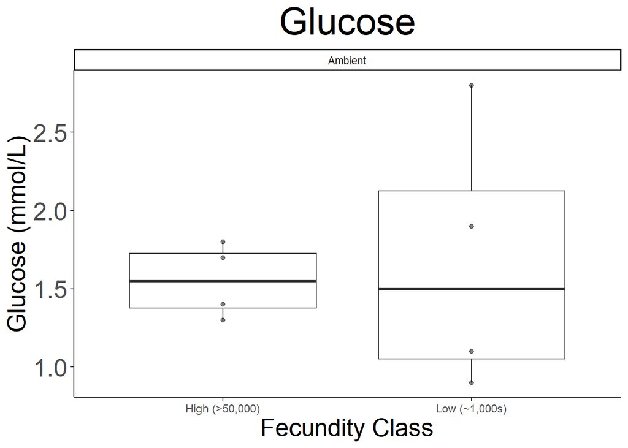

```r
# glucose boxplot

# Amb_Fec Samples No Atresia Ids
glucose_amb_fec_no_atresia_boxplot <- ggplot(data = Amb_Fec_No_Atresia_Samples) +
  geom_boxplot(aes(x = Fecundity_Class, y = Glu..mmol.L.)) +
  geom_point(aes(x = Fecundity_Class, y = Glu..mmol.L.), alpha = 0.5, colour = "black") +
  labs(title = "Glucose", x = "Fecundity Class", y = "Glucose (mmol/L)") +
   facet_wrap(~ Ambient.Or.OAH) +
  theme_classic() +
  theme(panel.background = element_rect(fill = "white"),
        plot.background = element_rect(fill = "white"),
        legend.background = element_rect(fill = "white", color = "black"),
        title = element_text(size = 12),
        plot.title = element_text(size = 30, hjust = 0.5),
        axis.text.x = element_text(size = 9),
        axis.text.y = element_text(size = 20),
        axis.title.x = element_text(size = 20),
        axis.title.y = element_text(size = 20))

print(glucose_amb_fec_no_atresia_boxplot)
```

```r
ggsave(filename = "data-images/glucose_amb_fec_no_atresia_boxplot.pdf", plot = glucose_amb_fec_no_atresia_boxplot, device = "pdf")
ggsave(filename = "data-images/glucose_amb_fec_no_atresia_boxplot.png", plot = glucose_amb_fec_no_atresia_boxplot, device = "png")
```

Glucose Boxplot

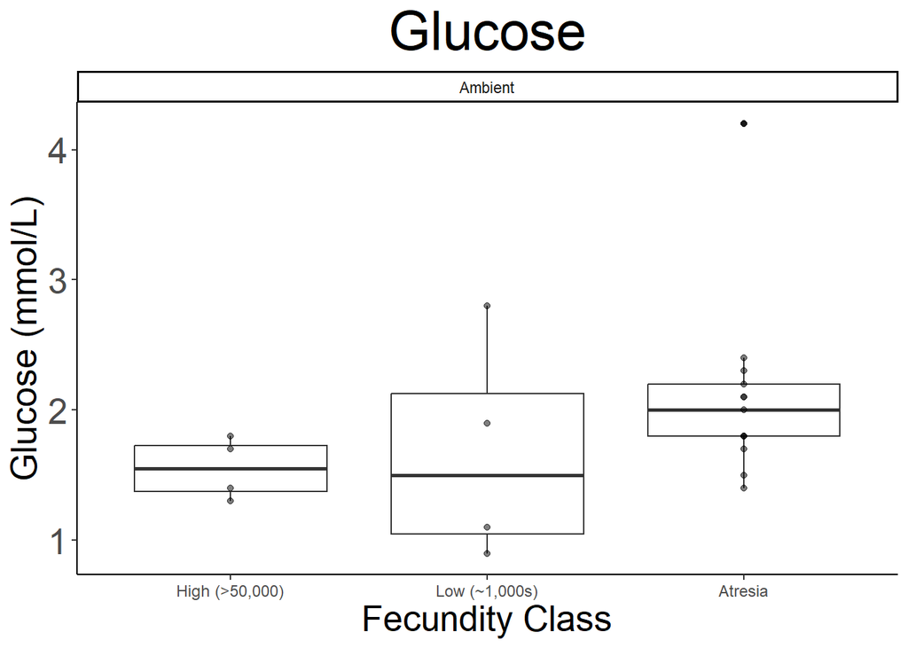

```r
# glucose boxplot

# Amb_Fec Samples with Atresia Ids
glucose_amb_fec_boxplot <- ggplot(data = Amb_Fec_Samples) +
  geom_boxplot(aes(x = Fecundity_Class, y = Glu..mmol.L.)) +
  geom_point(aes(x = Fecundity_Class, y = Glu..mmol.L.), alpha = 0.5, colour = "black") +
  labs(title = "Glucose", x = "Fecundity Class", y = "Glucose (mmol/L)") +
   facet_wrap(~ Ambient.Or.OAH) +
  theme_classic() +
  theme(panel.background = element_rect(fill = "white"),
        plot.background = element_rect(fill = "white"),
        legend.background = element_rect(fill = "white", color = "black"),
        title = element_text(size = 12),
        plot.title = element_text(size = 30, hjust = 0.5),
        axis.text.x = element_text(size = 9),
        axis.text.y = element_text(size = 20),
        axis.title.x = element_text(size = 20),
        axis.title.y = element_text(size = 20))

print(glucose_amb_fec_boxplot)
```

```r
ggsave(filename = "data-images/glucose_amb_fec_boxplot.pdf", plot = glucose_amb_fec_boxplot, device = "pdf")
ggsave(filename = "data-images/glucose_amb_fec_boxplot.png", plot = glucose_amb_fec_boxplot, device = "png")
```

Glucose Parametric Assessment Data Distribution

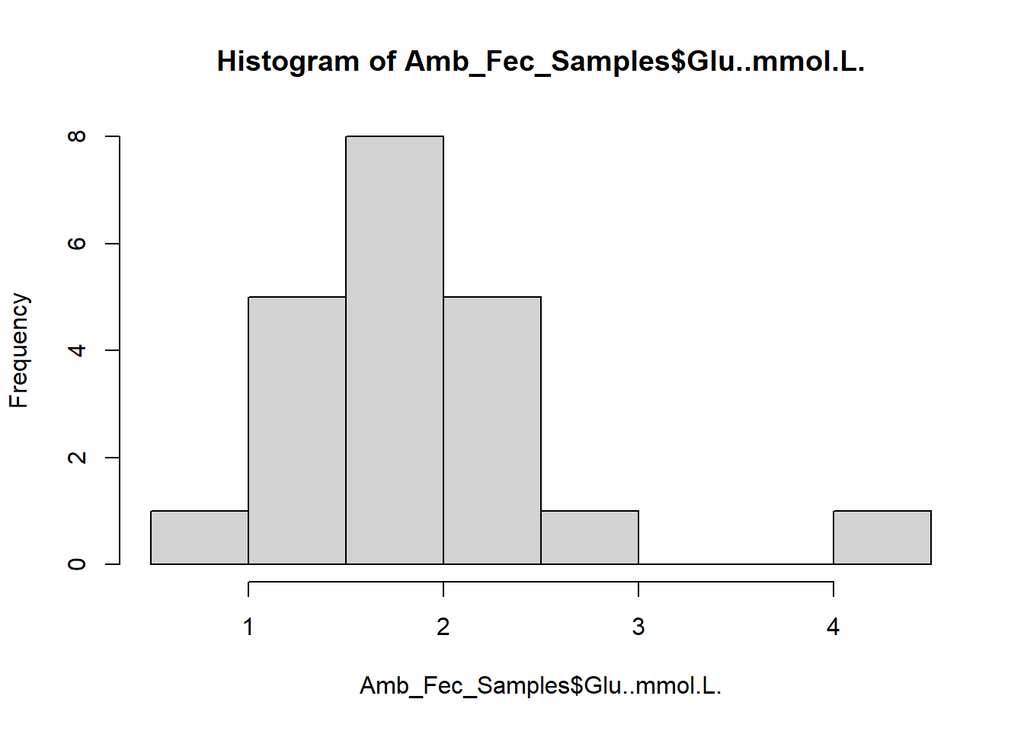

```r
# glucose
# Parametric Assumptions

# Data Distribution


# Amb Fec Samples
# Frequency Histograms

hist(Amb_Fec_Samples$Glu..mmol.L.)
```

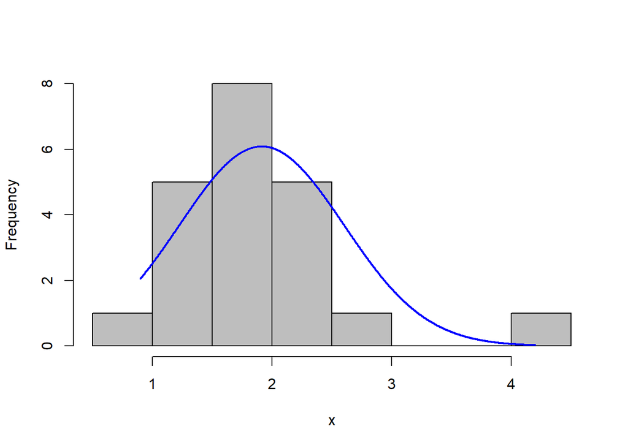

```r
plotNormalHistogram(Amb_Fec_Samples$Glu..mmol.L.)
```

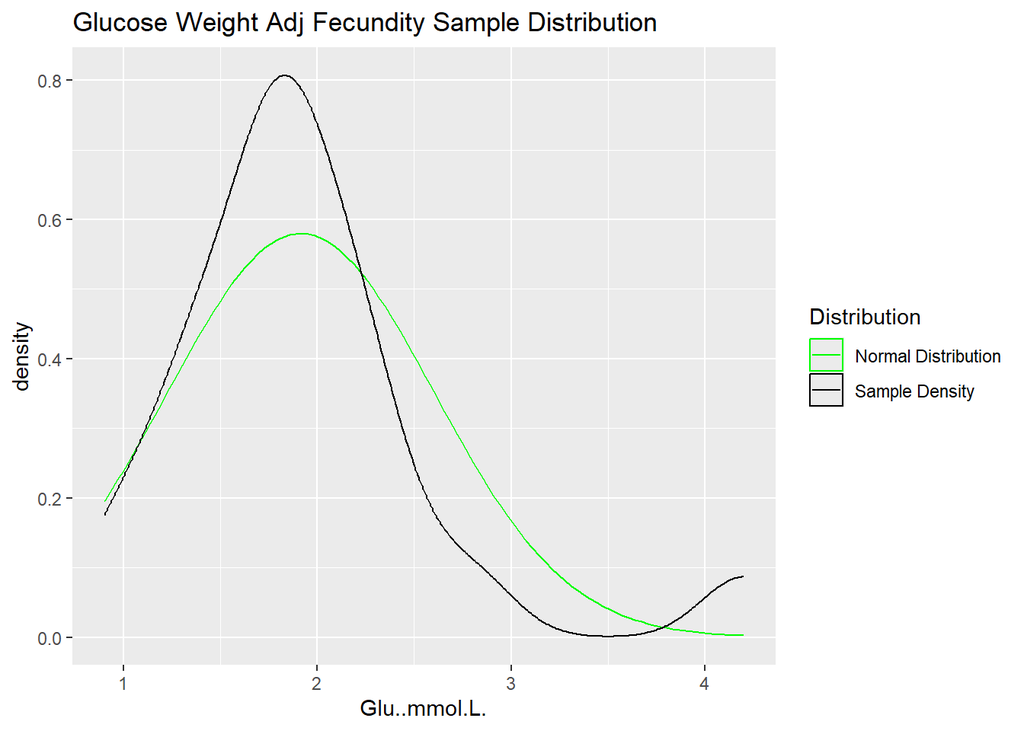

```r
# Density plot

Amb_Fec_Samples %>%
  ggplot(aes(x = Glu..mmol.L.)) +
  stat_function(fun = dnorm, args = c(mean = mean(Amb_Fec_Samples$Glu..mmol.L.), sd = sd(Amb_Fec_Samples$Glu..mmol.L.)), aes(col = "Normal Distribution"), show.legend = TRUE) +
  geom_density(aes(col = "Sample Density"), show.legend = TRUE) +
  labs(title = "Glucose Weight Adj Fecundity Sample Distribution") +
  scale_color_manual("Distribution", values = c("Normal Distribution" = "green", "Sample Density" = "black"))
```

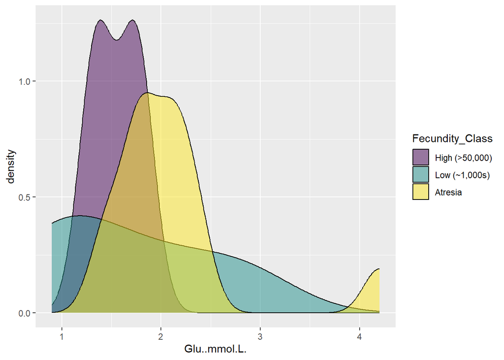

```r
# Density by brood condition
Amb_Fec_Samples %>%
ggplot(aes(x = Glu..mmol.L.)) +
  geom_density(aes(x = Glu..mmol.L., fill = Fecundity_Class), alpha = 0.5)
```

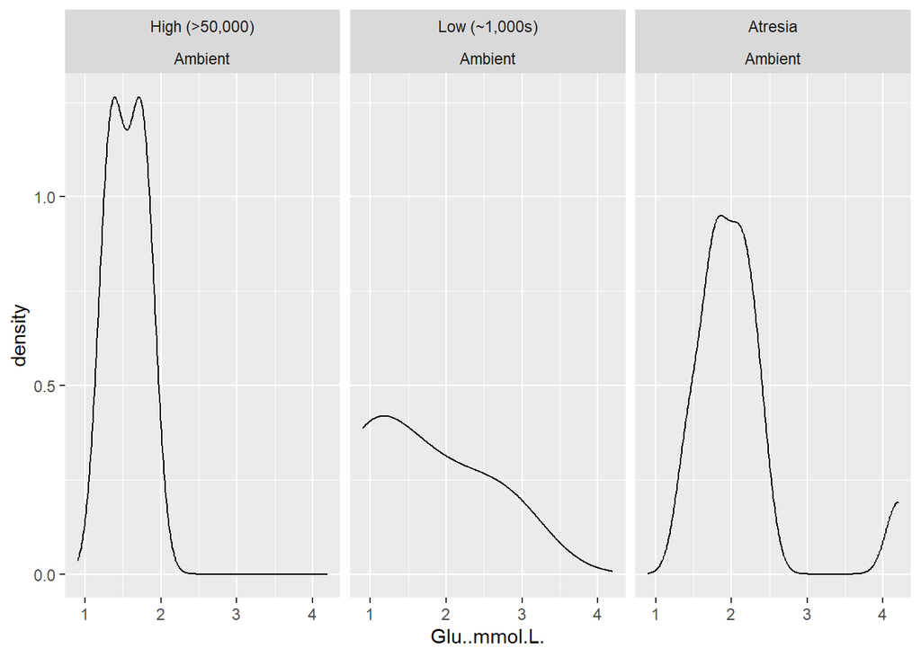

```r
ggplot(Amb_Fec_Samples, aes(x = Glu..mmol.L.)) +
  geom_density(aes(x = Glu..mmol.L.)) +
  facet_wrap(Fecundity_Class ~ Ambient.Or.OAH)
```

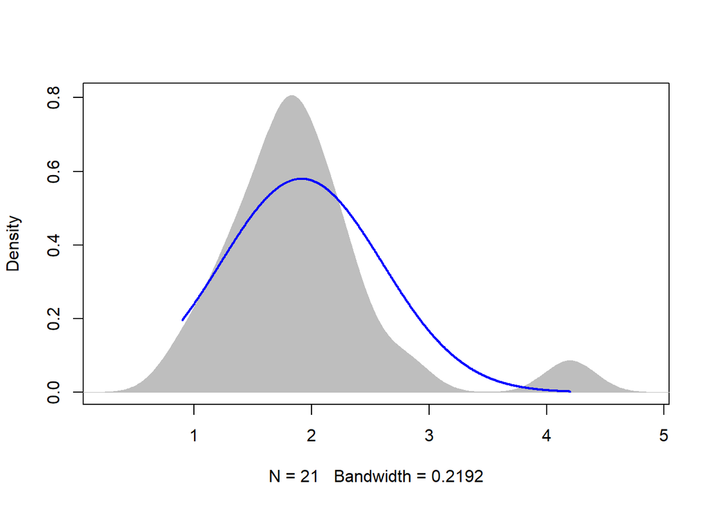

```r
plotNormalDensity(Amb_Fec_Samples$Glu..mmol.L.)
```

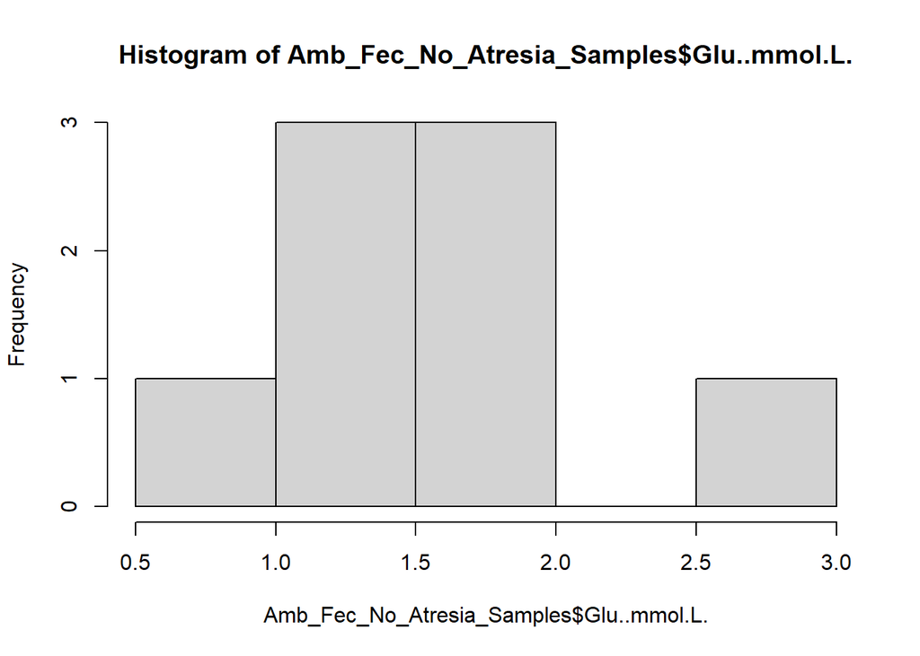

```r
# glucose

# Amb Fec No Atresia Samples
# Frequency Histograms

hist(Amb_Fec_No_Atresia_Samples$Glu..mmol.L.)
```

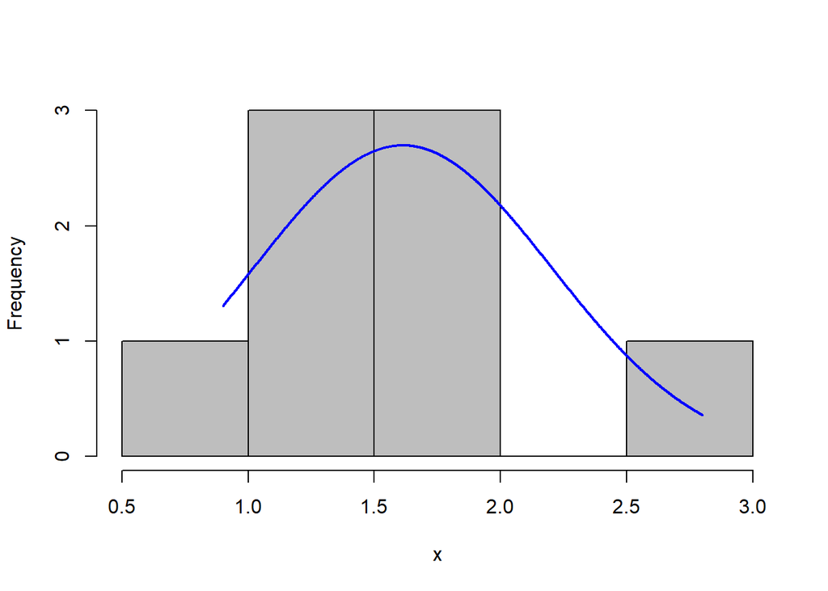

```r
plotNormalHistogram(Amb_Fec_No_Atresia_Samples$Glu..mmol.L.)
```

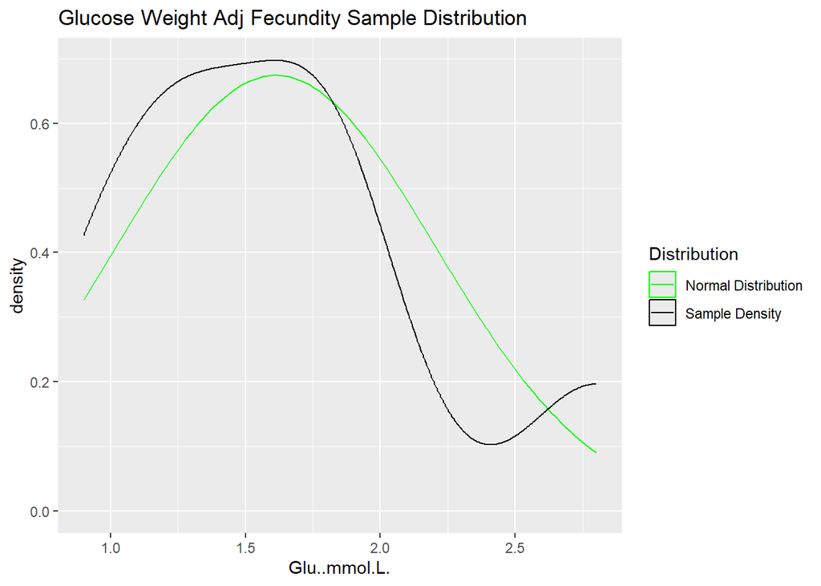

```r
# Density plot

Amb_Fec_No_Atresia_Samples %>%
  ggplot(aes(x = Glu..mmol.L.)) +
  stat_function(fun = dnorm, args = c(mean = mean(Amb_Fec_No_Atresia_Samples$Glu..mmol.L.), sd = sd(Amb_Fec_No_Atresia_Samples$Glu..mmol.L.)), aes(col = "Normal Distribution"), show.legend = TRUE) +
  geom_density(aes(col = "Sample Density"), show.legend = TRUE) +
  labs(title = "Glucose Weight Adj Fecundity Sample Distribution") +
  scale_color_manual("Distribution", values = c("Normal Distribution" = "green", "Sample Density" = "black"))
```

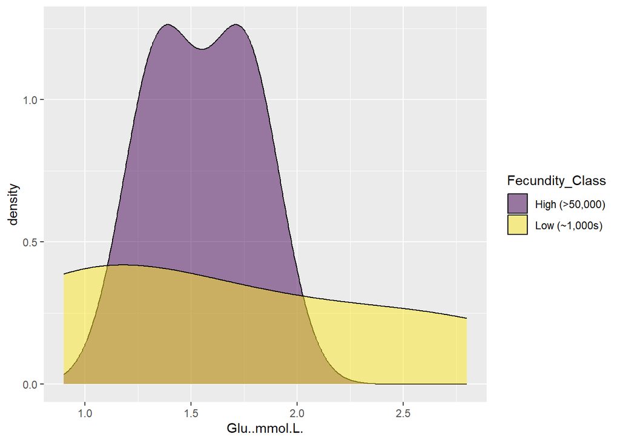

```r
# Density by brood condition
Amb_Fec_No_Atresia_Samples %>%
ggplot(aes(x = Glu..mmol.L.)) +
  geom_density(aes(x = Glu..mmol.L., fill = Fecundity_Class), alpha = 0.5)
```

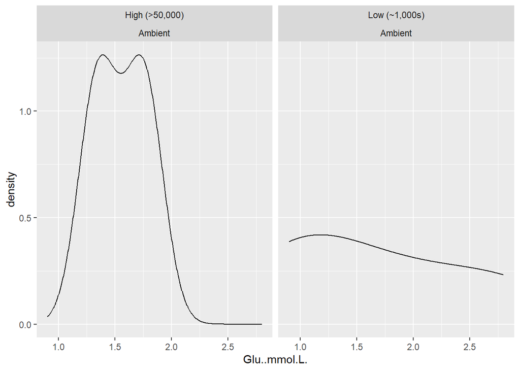

```r
ggplot(Amb_Fec_No_Atresia_Samples, aes(x = Glu..mmol.L.)) +
  geom_density(aes(x = Glu..mmol.L.)) +
  facet_wrap(Fecundity_Class ~ Ambient.Or.OAH)
```

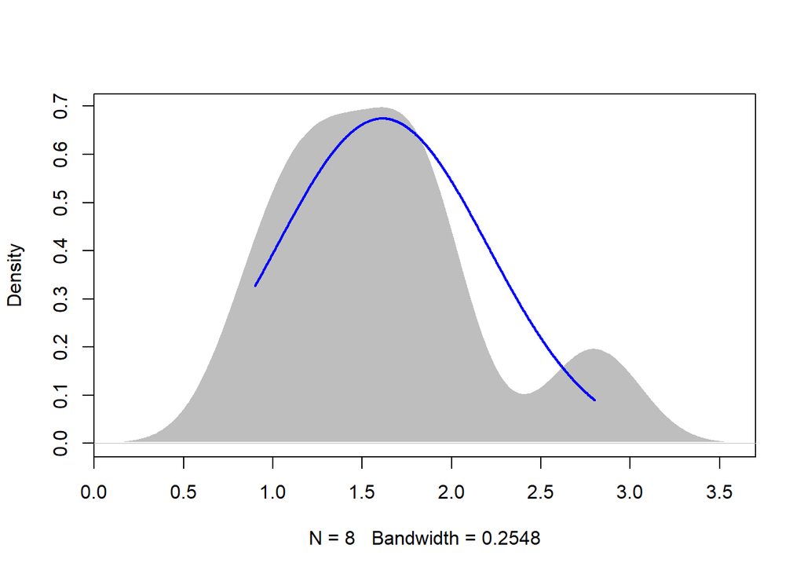

```r
plotNormalDensity(Amb_Fec_No_Atresia_Samples$Glu..mmol.L.)
```

# Glucose Stat Tests

Model Design

```r
# glucose

# Amb Fec No Atresia regression model

glucose_amb_fec_no_atresia_lm <- lm(Glu..mmol.L. ~ All_Fecundity, data = Amb_Fec_No_Atresia_Samples)

glucose_amb_fec_no_atresia_lm_res <- residuals(glucose_amb_fec_no_atresia_lm)

# p-value significant if (a < 0.1 or a < 0.05)
summary(glucose_amb_fec_no_atresia_lm)
```

```
##
## Call:
## lm(formula = Glu..mmol.L. ~ All_Fecundity, data = Amb_Fec_No_Atresia_Samples)
##
## Residuals:
##     Min      1Q  Median      3Q     Max
## -0.6868 -0.2944 -0.1433  0.1285  1.2066
##
## Coefficients:
##                Estimate Std. Error t value Pr(>|t|)
## (Intercept)   1.359e+00  4.773e-01   2.848   0.0293 *
## All_Fecundity 4.852e-06  8.120e-06   0.597   0.5720
## ---
## Signif. codes:  0 '***' 0.001 '**' 0.01 '*' 0.05 '.' 0.1 ' ' 1
##
## Residual standard error: 0.6206 on 6 degrees of freedom
## Multiple R-squared:  0.05616,    Adjusted R-squared:  -0.1012
## F-statistic: 0.357 on 1 and 6 DF,  p-value: 0.572
```

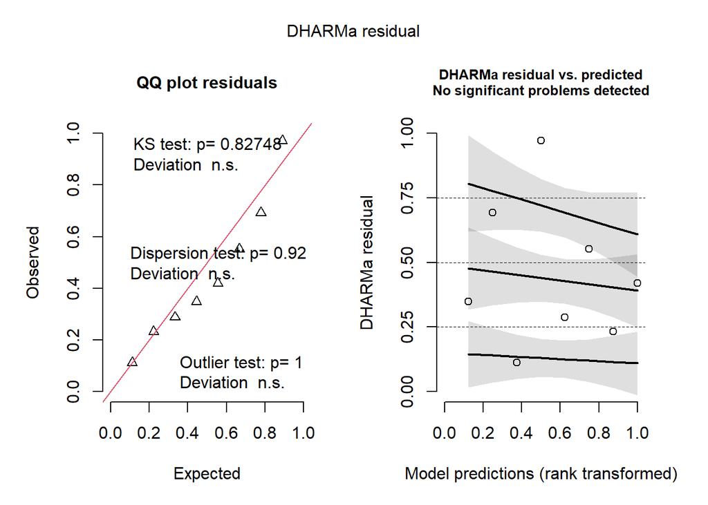

```r
glucose_amb_fec_no_atresia_lm_res_plot <- simulateResiduals(fittedModel = glucose_amb_fec_no_atresia_lm)
plot(glucose_amb_fec_no_atresia_lm_res_plot)
```

```r
# Normality test
shapiro.test(glucose_amb_fec_no_atresia_lm_res)
```

```
##
##  Shapiro-Wilk normality test
##
## data:  glucose_amb_fec_no_atresia_lm_res
## W = 0.89353, p-value = 0.2523
```

```r
# scedasticity test requires a categorical variable
```

Results: Ambient Fecundity No Atresia Sample

Parametric Assumptions:

- Sample size (n > 30): **Not Met**
- Normality: **Met**, shapiro.test p-value = 0.2523**
- Homoscedasticity: **???**

Model For Fecundity Class (No Atresia)

```r
# glucose
# Amb Fec No Atresia Class regression model

glucose_amb_fec_no_atresia_aov_cat <- aov(Glu..mmol.L. ~ Fecundity_Class, data = Amb_Fec_No_Atresia_Samples)

summary(glucose_amb_fec_no_atresia_aov_cat)
```

```
##                 Df Sum Sq Mean Sq F value Pr(>F)
## Fecundity_Class  1 0.0312  0.0312   0.078   0.79
## Residuals        6 2.4175  0.4029
```

```r
TukeyHSD(glucose_amb_fec_no_atresia_aov_cat)
```

```
##   Tukey multiple comparisons of means
##     95% family-wise confidence level
##
## Fit: aov(formula = Glu..mmol.L. ~ Fecundity_Class, data = Amb_Fec_No_Atresia_Samples)
##
## $Fecundity_Class
##                               diff        lwr      upr     p adj
## Low (~1,000s)-High (>50,000) 0.125 -0.9732745 1.223275 0.7899814
```

```r
# Normality test
shapiro.test(Amb_Fec_No_Atresia_Samples$Glu..mmol.L.)
```

```
##
##  Shapiro-Wilk normality test
##
## data:  Amb_Fec_No_Atresia_Samples$Glu..mmol.L.
## W = 0.92763, p-value = 0.4947
```

```r
# Parametric variance test:
# Bartlett's test requires a categorical variable
bartlett.test(Glu..mmol.L. ~ Fecundity_Class, data = Amb_Fec_No_Atresia_Samples)
```

```
##
##  Bartlett test of homogeneity of variances
##
## data:  Glu..mmol.L. by Fecundity_Class
## Bartlett's K-squared = 3.4491, df = 1, p-value = 0.06329
```

```r
# Unequal variance

# Non-parametric variance test:
# Levene's test requires a categorical variable
LeveneTest(Glu..mmol.L. ~ Fecundity_Class, data = Amb_Fec_No_Atresia_Samples)
```

```
## Levene's Test for Homogeneity of Variance (center = median)
##       Df F value  Pr(>F)
## group  1  4.8565 0.06974 .
##        6
## ---
## Signif. codes:  0 '***' 0.001 '**' 0.01 '*' 0.05 '.' 0.1 ' ' 1
```

```r
# Unequal variance by non-parametric standards

# Non-parametric stat test
kruskal.test(Glu..mmol.L. ~ Fecundity_Class, data = Amb_Fec_No_Atresia_Samples)
```

```
##
##  Kruskal-Wallis rank sum test
##
## data:  Glu..mmol.L. by Fecundity_Class
## Kruskal-Wallis chi-squared = 0, df = 1, p-value = 1
```

Results: Ambient Fecundity No Atresia Sample

- No significant difference in glucose between fecundity classes: Low (~1,000s) vs. High (>50,000) (p adj = 0.7899814)

Parametric Assumptions: Across Sample comparisons…

- Sample size (n > 30): **Not Met**
- Normality: **Met**
- Homoscedasticity: **Not Met, nonparametric**
- Evidence: Bartlett’s K-squared = 3.4491, df = 1, p-value = 0.06329
- Nonparametric variance test **Does not pass**
- Evidence: Levene’s Test for Homogeneity of Variance (center = median), F value = 4.8565, Pr(>F) = 0.06974

Levene’s Test Pr(>F) = 0.06974**

Non-Parametric Results: - No significant difference in glucose between fecundity classes: Low (~1,000s) vs. High (>50,000) - Evidence: Kruskal-Wallis rank sum test, p-value = 1

Model For Fecundity Class (With Atresia)

```r
# Glucose
# Amb Fec Class regression model

glucose_amb_fec_aov_cat <- aov(Glu..mmol.L. ~ Fecundity_Class, data = Amb_Fec_Samples)

summary(glucose_amb_fec_aov_cat)
```

```
##                 Df Sum Sq Mean Sq F value Pr(>F)
## Fecundity_Class  2  1.208  0.6041   1.317  0.293
## Residuals       18  8.257  0.4587
```

```r
TukeyHSD(glucose_amb_fec_aov_cat)
```

```
##   Tukey multiple comparisons of means
##     95% family-wise confidence level
##
## Fit: aov(formula = Glu..mmol.L. ~ Fecundity_Class, data = Amb_Fec_Samples)
##
## $Fecundity_Class
##                               diff        lwr      upr     p adj
## Low (~1,000s)-High (>50,000) 0.125 -1.0973103 1.347310 0.9632210
## Atresia-High (>50,000)       0.550 -0.4383693 1.538369 0.3518867
## Atresia-Low (~1,000s)        0.425 -0.5633693 1.413369 0.5277964
```

```r
# Normality test:
shapiro.test(Amb_Fec_Samples$Glu..mmol.L.)
```

```
##
##  Shapiro-Wilk normality test
##
## data:  Amb_Fec_Samples$Glu..mmol.L.
## W = 0.85634, p-value = 0.005473
```

```r
# Parametric variance test:
# Bartlett's test requires a categorical variable
bartlett.test(Glu..mmol.L. ~ Fecundity_Class, data = Amb_Fec_Samples)
```

```
##
##  Bartlett test of homogeneity of variances
##
## data:  Glu..mmol.L. by Fecundity_Class
## Bartlett's K-squared = 3.669, df = 2, p-value = 0.1597
```

```r
# Non-parametric variance test:
# Levene's test requires a categorical variable
#LeveneTest(Glu..mmol.L. ~ Fecundity_Class, data = Amb_Fec_Samples)

# Non-parametric stat test:
kruskal.test(Glu..mmol.L. ~ Fecundity_Class, data = Amb_Fec_Samples)
```

```
##
##  Kruskal-Wallis rank sum test
##
## data:  Glu..mmol.L. by Fecundity_Class
## Kruskal-Wallis chi-squared = 4.0755, df = 2, p-value = 0.1303
```

```r
DunnTest(Glu..mmol.L. ~ Fecundity_Class, data = Amb_Fec_Samples)
```

```
##
##  Dunn's test of multiple comparisons using rank sums : holm
##
##                              mean.rank.diff   pval
## Low (~1,000s)-High (>50,000)       2.625000 0.5480
## Atresia-High (>50,000)             6.663462 0.1778
## Atresia-Low (~1,000s)              4.038462 0.5060
## ---
## Signif. codes:  0 '***' 0.001 '**' 0.01 '*' 0.05 '.' 0.1 ' ' 1
```

Results: Ambient Fecundity Sample (With Atresia)

- **No significant** difference in glucose between fecundity classes: Low (~1,000s), High (>50,000), and Atresia
- Evidence: Pr(>F) = 0.293*

Parametric Assumptions: Across Sample comparisons…

- Sample size (n > 30): **Not Met**
- Normality: **Not Met, Shapiro-Wilk Test p-value = 0.005473**
- Homoscedasticity: **Met**

Non-parametric stat test results: - **No significant** difference in glucose between fecundity classes: Low (~1,000s), High (>50,000), and Atresia - Evidence: Kruskal-Wallis chi-squared = 4.0755, df = 2, p-value = 0.1303